# HW 1 Key

## Enter your name and EID here

**This homework is due on January 28, 2022 by 11:59pm. You will submit a pdf file on Gradescope.**

*For all questions, include the R code that you used to find your answer (show R chunk and outputs). Answers without supporting code will not receive credit (unless no code was required). Outputs without comments will not receive credit either: Write full sentences to describe your findings.*

### Question 1: (2 pts)

##### The dataset `mtcars` was extracted from the 1974 Motor Trend US magazine, and comprises fuel consumption and other aspects of automobile design and performance for different cars (1973–74 models). Look up the documentation for this data frame with a description of the variables by typing `?mtcars` in the console pane. Take a look at the first 6 rows of the dataset by using an `R` function in the code chunk below. Do you know about any (or all) of these cars?

```r
# Look at the first 6 rows of the dataset
head(mtcars)
```

```
##                    mpg cyl disp  hp drat    wt  qsec vs am gear carb
## Mazda RX4         21.0   6  160 110 3.90 2.620 16.46  0  1    4    4
## Mazda RX4 Wag     21.0   6  160 110 3.90 2.875 17.02  0  1    4    4
## Datsun 710        22.8   4  108  93 3.85 2.320 18.61  1  1    4    1
## Hornet 4 Drive    21.4   6  258 110 3.08 3.215 19.44  1  0    3    1
## Hornet Sportabout 18.7   8  360 175 3.15 3.440 17.02  0  0    3    2
## Valiant           18.1   6  225 105 2.76 3.460 20.22  1  0    3    1
```

*I didn’t know about any of these cars. (answers will vary)*

### Question 2: (2 pts)

##### How many rows and columns are there in this data frame in total?

*There are* 32 *rows and* 11 *columns in this data frame (no R code needed).*

### Question 3: (2 pts)

##### When is your birthday? Grab the value of `mpg` that corresponds to the day of your birthday (should be a number between 1 and 31).

```r
# Grab the value of `mpg` that corresponds to the day of my birthday
mtcars$mpg[14]
```

```
## [1] 15.2
```

```r
# other ways are possible
```

*The value of mpg corresponding to my birthday is 15.2 mpg. (answers will vary)*

### Question 4: (2 pts)

##### Recall how logical indexing of a data frame works in R. To refresh your memory, in the example code below I ask R for the number of rows in the dataset where the variable `mpg` takes on values greater than 30. What is the comma doing in the code below (i.e., why is it necessary)?

```r
# Find the number of rows with nrow()
nrow(mtcars[mtcars$mpg > 30, ])
```

```
## [1] 4
```

*We index the full dataset, so the comma is necessary to specify row indexing (rows before the comma, columns after).*

### Question 5: (2 pts)

##### Find the mean value of the numeric variable of your choice among: `disp`, `hp`, `drat`, `wt`, or `qsec`. Make sure to report the mean with its corresponding unit.

```r
# Calculate the mean
mean(mtcars$disp)
```

```
## [1] 230.7219
```

*The mean displacement is approximately 230.7 cubic inches. (answers will vary)*

### Question 6: (4 pts)

##### Let’s make a plot in base R. Create a scatterplot to investigate the relationship between `mpg` and the numeric variable of your choice among: `disp`, `hp`, `drat`, `wt`, or `qsec`. Make sure to give a title to the graph. Comment on the relationship.

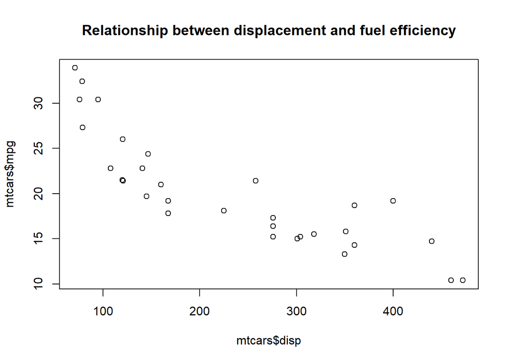

```r
# Create a scatterplot
plot(mtcars$disp, mtcars$mpg,
     main = "Relationship between displacement and fuel efficiency")
```

*As the displacement increases, the fuel efficiency decreases. (answers will vary)*

### Question 7: (3 pts)

##### Check that your code is well documented with comments in the R chunks. Make sure you wrote sentences and reported units when necessary.

*No answer needed*

### Question 8: (3 pts)

##### Knit your file into html. Is it working? If not, try to decipher the error message (look up the error message, consult websites such as [stackoverflow](https://stackoverflow.com/) or [crossvalidated](https://stats.stackexchange.com/). Once it knits and the html window pops out, click on `Open in Browser` at the top left. Print your html file into pdf from your browser. Any issue? Ask your classmates, come by student hours!

*No answer needed*

[output not shown]